# “PSY 8712 Week 8 Project”

Minjeong Seo

2024-03-18

# **Reproducible Image and Online Resources**

# **Script Settings and Resources**

I used message to suppress all output from a chunk but display a copy of the executed code. Just because message suppress any informational messages.

```r
setwd(dirname(rstudioapi::getActiveDocumentContext()$path))
library(tidyverse)
```

# **Data Import and Cleaning**

This chunk is for importing and cleaning data. I used read_csv to import data, mutate to change data types, and rowwise with mutate and mean to prepare section 4.

```r
week8_tbl <- read_csv("../data/week3.csv") %>%
  mutate(q5 = 6 - q5) %>%
  mutate(timeStart = ymd_hms(timeStart)) %>%
  mutate(timeEnd = ymd_hms(timeEnd)) %>%
  mutate(condition = factor(condition, levels = c("A", "B", "C"), labels = c("Block A", "Block B", "Control"))) %>%
  mutate(gender = factor(gender, levels = c("M", "F"), labels = c("Male", "Female"))) %>%
  rowwise() %>%
  mutate(meanQ1_6 = mean(c(q1, q2, q3, q4, q5, q6))) %>%
  mutate(meanQ8_10 = mean(c(q8, q9, q10)))
```

# **Visualization**

This chunk is for visualizing the table (Q1~Q6) and the scatter plot (mean Q1-Q6 and mean Q8-Q10) with the OLS regression line. To visualize the table and plot, I used the select function with df_print in the YAML and ggplot with geom_point(to make the scatter plot) and geom_smooth(to add OLS regression line) .

```r
week8_tbl %>%
  select(q1:q6)
```

| q1 | q2 | q3 | q4 | q5 | q6 |
| --- | --- | --- | --- | --- | --- |
| 5 | 4 | 4 | 1 | 2 | 1 |
| 2 | 4 | 3 | 1 | 3 | 1 |
| 5 | 5 | 2 | 1 | 5 | 1 |
| 4 | 3 | 4 | 2 | 4 | 1 |
| 3 | 1 | 3 | 5 | 2 | 1 |
| 4 | 3 | 2 | 3 | 3 | 1 |
| 2 | 4 | 1 | 3 | 1 | 1 |
| 4 | 2 | 5 | 1 | 1 | 1 |
| 2 | 5 | 3 | 4 | 2 | 1 |
| 3 | 4 | 2 | 4 | 5 | 1 |

[output cut: 39 more lines]

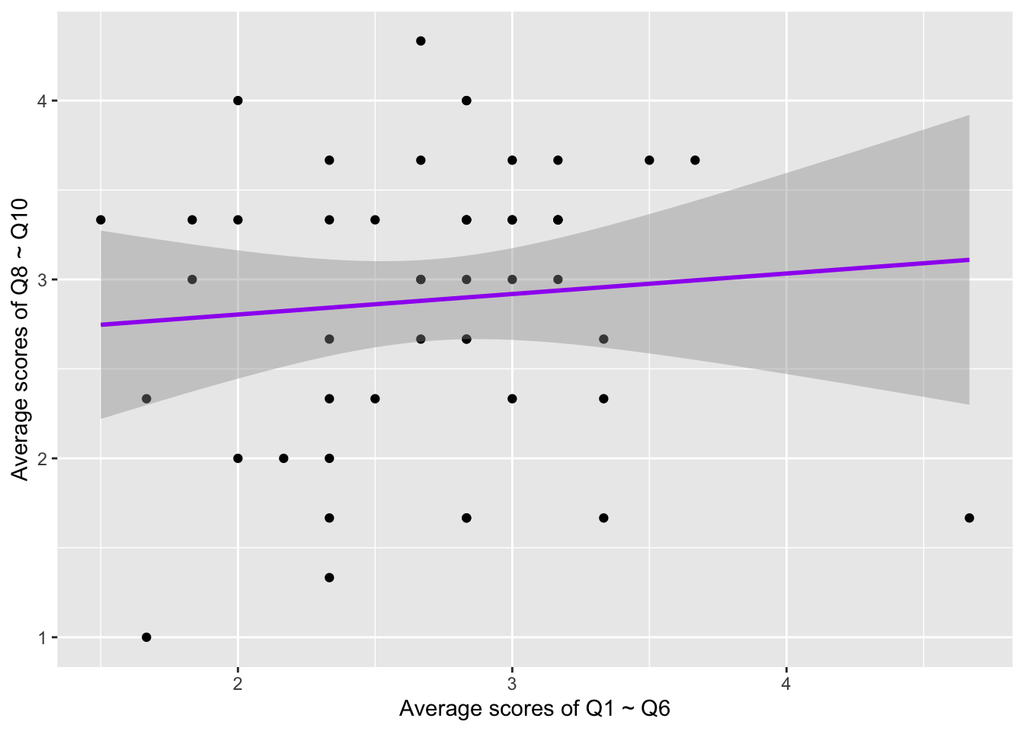

```r
week8_tbl %>%
  ggplot(aes(x = meanQ1_6, y = meanQ8_10)) +
  geom_point() +
  geom_smooth(method = "lm", color = "purple") +
  labs(x = "Average scores of Q1 ~ Q6", y = "Average scores of Q8 ~ Q10")
```

# **Analysis**

This chunk is used to obtain the correlation between mean Q1-Q6 and mean Q8-Q10. I observed a correlation of 0.08

```r
cor.test(week8_tbl$meanQ1_6, week8_tbl$meanQ8_10)
```

```
##
##  Pearson's product-moment correlation
##
## data:  week8_tbl$meanQ1_6 and week8_tbl$meanQ8_10
## t = 0.58309, df = 47, p-value = 0.5626
## alternative hypothesis: true correlation is not equal to 0
## 95 percent confidence interval:
##  -0.2012466  0.3574248
## sample estimates:
##        cor
## 0.08474575
```